# FLIC: Data Analysis Part 1: Introduction and DFM Data (Version 4.x)

Scott Pletcher and the Pletcher Lab

4/27/2022

## Overview

This document begins a series of markdown files that contain working examples that will hopefully make it easier to understand how we analyze the signal data from FLIC DFMs. We have written many R functions that we find useful for analyzing simple feeding experiments that involve one feeding well per chamber as well as choice experiments that involve two feeding wells per chamber. These markdown files currently serve as the documentation for all functions. The source code is (semi) commented and available from GitHub (https://github.com/PletcherLab/FLIC_R_Code). The example data files are available in the repository as an archived (i.e., zipped) file. You may also contact Scott if you have specific questions or would like to interrogate your data in a specific way that doesn’t appear to be supported in the code.

As with all FLIC R code, this is a work in progress. If you decide to extend this code and wish to share it with the community, please contact Scott.

## Getting Started

1. Download and install the latest version of [R](https://cran.r-project.org/) or [Microsoft Open R](https://mran.microsoft.com/open) for your operating system.
2. Download R studio (https://www.rstudio.com/) and install it.
3. Create a new folder on your hard drive to serve as the project directory.
4. Copy all of DFM data files (e.g., “DFM_1.csv”) to that folder.
5. Clone the Github Respository or download the files as a zip file. Unzip or copy the .R files and/or the FLICFUNCTIONS file to the project directory. The Master branch will always hold the most up-to-date code, but previous versions are tagged for download as well.
6. Start R studio. Choose File|New Project and click “Existing Directory.” Point to your project folder. R Studio will set the default directly to your project folder. You are ready to start analyzing your feeding interaction data!
7. You will need to ensure that you have the following R packages installed: *ggplot2*, *stats*, *reshape2*, and *gridExtra*. If you are new to R, you can find lots of information about packages and installing them in RStudio with a simple web search (e.g., [here](https://www.datacamp.com/community/tutorials/r-packages-guide) and [here](http://web.cs.ucla.edu/~gulzar/rstudio/))
8. All relevant files used for the example analyses are provided in the *ExampleData.zip* file. To run the examples, you will need to extract these files into the project directory.

There are two options for providing access to the FLIC functions. Attach the R object to the search path (assuming the file in is the working directory), preferably in a search position higher than 1 (note the *pos=2* argument to *attach()*) so that the function definitions don’t clutter your working environment.

```r
library(ggplot2)
library(stats)
library(gridExtra)
library(reshape2)
library(gtools)
attach("FLICFunctions",pos=2)
```

Alternatively, you may copy all of the R files to the project directory and source the one that are required.

```r
source("FLICUserFunctions.R")
```

## Loading DFM Data

The FLIC analysis code is loosely based on an object oriented concept,although R itself is not OOP friendly.Some functions will therefore include “Class” in their name. These create “objects” that will contain the data or other relevant information. To signify the type of data that we have and the parameters that will be used to identify food interactions, we first need to create a parameters object. For this example, we would like a set of default parameters for a choice chamber in which two feeding wells are presented in each behavioral chamber as a food choice.

```r
p.choice<-ParametersClass.TwoWell()
```

Examine the components of this object.

```r
attributes(p.choice)
```

```
## $names
##  [1] "Baseline.Window.Minutes" "Feeding.Threshold"
##  [3] "Feeding.Minimum"         "Tasting.Minimum"
##  [5] "Tasting.Maximum"         "Feeding.Minevents"
##  [7] "Tasting.Minevents"       "Samples.Per.Second"
##  [9] "Chamber.Size"            "Chamber.Sets"
## [11] "Feeding.Event.Link.Gap"  "PI.Multiplier"
```

and their respective default values.

```
## $Baseline.Window.Minutes
## [1] 3
##
## $Feeding.Threshold
## [1] 20
##
## $Feeding.Minimum
## [1] 10
##
## $Tasting.Minimum
## [1] 5
##
## $Tasting.Maximum
## [1] 20
##
## $Feeding.Minevents
## [1] 1
##
## $Tasting.Minevents
## [1] 1
##
## $Samples.Per.Second
## [1] 5
##
## $Chamber.Size
## [1] 2
##
## $Chamber.Sets
##      [,1] [,2]
## [1,]    1    2
## [2,]    3    4
## [3,]    5    6
## [4,]    7    8
## [5,]    9   10
## [6,]   11   12
##
## $Feeding.Event.Link.Gap
## [1] 5
##
## $PI.Multiplier
## [1] 1
```

| Parameter | Definition |
| --- | --- |
| Baseline.Window.Minutes | The window size (in minutes) used to normalize the (i.e., non-feeding) signal to zero. |
| Feeding.Threshold | The normalized signal above which a feeding interaction is indicated to have occured. |
| Feeding.Minimum | The minimum normalized signal indicating a feeding interaction (must link to a signal above threshold). |
| Tasting.Minimum | A normalized signal is considered to be generated by a fly if it is not a feeding interaction |
| Tasting.Maximum | and lies between Tasting.Minimum and Tasting.Maximum. |
| Feeding.Minevents | The number of consecutive feeding signals required to constitute a feeding event. |
| Tasting.Minevents | The number of consecutive tasting signals required to constitute a tasting event. |
| Samples.Per.Second | The sample frequency of signal capture (normally 5 for the standard MCU). Do not modify. |
| Chamber.Size | The number of feeding wells in a behavioral chamber. Will be two for a choice analysis. Do not modify. |
| Chamber.Sets | Encoding of chamber numerical IDs to their position on the physical DFM. Do not modify. |
| Feeding.Event.Link.Gap | Contiguous periods of interaction (licks) will be combined into single events if gaps of inactivity between them are less than this time (in seconds). |
| PI.Multiplier | Used to indicate the orientation of food choices on each DFM. Can be -1 or 1. (e.g., 1 indicates left well is WellA). |

Note that the feeding- and tasting-related parameters are critical for determining all feeding interactions. We have set the default values to those we commonly use in the Pletcher lab, but you may change them using the SetParameter function, which takes the current parameter object as its first argument, followed by one or more parameters to set and their new values. Don’t forget to reassign the new object. To avoid biasing your tasting data, make sure that Tasting.Maximum <= Feeding.Minimum.

```r
p.choice<-SetParameter(p.choice,Feeding.Threshold=30)
p.choice<-SetParameter(p.choice,Feeding.Minimum=20)
p.choice<-SetParameter(p.choice,Tasting.Interval=c(10,20)) # Tasting.Interval defines minimum and maximum.
```

```
## $Baseline.Window.Minutes
## [1] 3
##
## $Feeding.Threshold
## [1] 30
##
## $Feeding.Minimum
## [1] 20
##
## $Tasting.Minimum
## [1] 10
##
## $Tasting.Maximum
## [1] 20
##
## $Feeding.Minevents
## [1] 1
##
## $Tasting.Minevents
## [1] 1
##
## $Samples.Per.Second
## [1] 5
##
## $Chamber.Size
## [1] 2
##
## $Chamber.Sets
##      [,1] [,2]
## [1,]    1    2
## [2,]    3    4
## [3,]    5    6
## [4,]    7    8
## [5,]    9   10
## [6,]   11   12
##
## $Feeding.Event.Link.Gap
## [1] 5
##
## $PI.Multiplier
## [1] 1
```

For now we will accept the default values.

```r
p.choice<-ParametersClass.TwoWell()
```

If you are executing single well experiments, you would create the relevant parameter object:

```r
p.single<-ParametersClass.SingleWell()
```

To load DFM data, you must create DFM classes for each. The *DFMClass()* function loads data from the appropriate .csv file, does a significant number of calculations, creates a dfm object in the working environment (e.g., DFM3, DFM6, etc.), and returns the DFM object. There is no explicit need to assign the returned object, because the background objected is created, but it can often be useful. If this variable is not needed, you should remove it afterward. When loading single DFMs it is best to assign the result regardless, to avoid a lengthy output. In the following code, we assign the results to a dummy variable (*dfm*) to suppress the output to the console.

The *DFMClass()* function takes the DFM ID as the first argument and a parameters object as the second argument.The associated .cvs files must be in the working/project directory. For the examples presented here, we will use data from two experiments: an 18-hour single-well feeding experiment in DFMs 1-4, and a 6 hour choice experiment in DFMs 11-17. To load data from a few of these DFMs,

```r
dfm.single<-DFMClass(3,p.single)
```

```
## [1] "Reading DFMV2 File: DFM_3.csv"
```

```r
dfm.choice<-DFMClass(11,p.choice)
```

```
## [1] "Reading DFMV2 File: DFM_11.csv"
```

```r
dfm12<-DFMClass(12,p.choice)
```

```
## [1] "Reading DFMV2 File: DFM_12.csv"
```

```r
rm(dfm12) #Note that this does not remove the background object, DFM12.
```

In this case we passed the same parameters object to both DFM11 and DFM12, meaning the same thresholds will be applied to each of the chambers and wells in both DFM (after baseline normalization for each DFM individually). Note also that both PI.Multipliers are the same, implying the food on the left is WellA on each DFM (see the *ChoiceChamberAnalysis.html* documentation for details).

FLIC data files and R objects can be quite large (sometimes prohibitively so) and you may find that you do not need to analyze data from the entire experiment. You can limit the range of data that is loaded by specifying a range parameter (in minutes) to the DFMClass function. For example, to load the first two hours of data from one of the DFM in the single-well experiment

```r
dfm.focussed<-DFMClass(2,p.single,range=c(0,120))
```

```
## [1] "Reading DFMV2 File: DFM_2.csv"
```

```r
rm(dfm.focussed) #Note that this does not remove the background object, DFM2.
```

## Feeding and Tasting Interactions

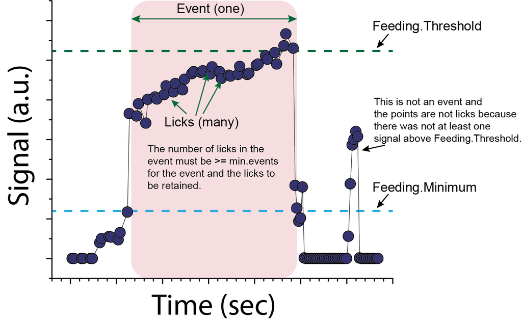

Figure 1. Thresholding Concept

All of these components are saved and make up the DFM object. You can explore them on your own if you wish, and we recommend that. They are, however, used automatically in all of the analysis functions, so a deep understanding is not required to complete stardard analyses. Please contact Scott if you would like additional details.

```r
DFM3<-ChangeParameterObject(DFM3,p.choice)
```

One can also do this by calling the *DFMClass()*.

```r
tmp<-DFMClass(3,p.single)
rm(tmp)
```

As mentioned previously, there are many components of a DFM object.

```r
attributes(dfm.single)
```

```
## $names
##  [1] "ID"               "Parameters"       "RawData"          "BaselineData"
##  [5] "Thresholds"       "LickData"         "EventData"        "TastingData"
##  [9] "TastingEventData" "Durations"        "Intervals"        "TastingDurations"
## [13] "TastingIntervals"
##
## $class
## [1] "DFM"
```

**NOTE:** To avoid the need to recalculate all of the DFM components each time a parameter is changed, the software will first determine whether there is a DFM object saved in the environment (e.g., DFM1 object). If so, it will only perform the above calculations that were invalidated by the parameter change. It will NOT automatically reload the data. To ensure that the data are reloaded from the .cvs file, you will either need to manually delete the relevant background DFM object or use the CleanDFM() function, which will delete all background DFM objects.

```r
rm(DFM3)
CleanDFM()
```

If there are apparent lapses in data collection that amount to more than 1 sec (DFMs collect data at roughly 500Hz and report average signals every 200ms), a warning will be printed. A closer examination of the problem can be had by using the *FindDataBreaks()* function. Data lapses can happen if the communication signals are noisy, for example when the DFMs are placed in an incubator. They are normally not a problem unless they reach several seconds to one minute. Large data breaks will be interpreted as periods of no feeding, so they need to be avoided. Most often they can not be corrected because they arise from a failure during data collection. Normally, they should not happen. Contact Scott if you receive this warning often.

```r
FindDataBreaks(DFM11)
```

```
## [1] NA
```

A return value of *NA* indicates that there are no databreaks.

## Interrogating the Data

The majority of the functions in this section are considered part of the *back end* but can be accessed by the user in the same way as the more common analysis functions. You can find these functions in the *PrivateData.R* file if you are interested.

You can output the first and last observation, which is often useful to ensure that the duration of the experiment is as expected. The *Minutes* and *Seconds* columns provide the elapsed time of the experiment.

```r
FirstSampleData(dfm.single)
```

```
##        Minutes Seconds      Date       Time MSec Sample W1 W2 W3 W4 W5 W6 W7 W8
## 1 3.333333e-05   0.002 7/19/2019 4:15:01 PM    2      4  0  0  0  0 -1  0 -1  0
##   W9 W10 W11 W12 Temp Humid  LUX Dark OptoFreq OptoPW OptoCol1 OptoCol2
## 1  0   0   0   1 22.5  62.5 35.7    0       40      8       63       63
```

```r
LastSampleData(dfm.single)
```

```
##        Minutes Seconds      Date        Time MSec Sample W1 W2 W3 W4 W5 W6 W7
## 323573 1079.99 64799.4 7/20/2019 10:15:00 AM  402 323576  0  0  0  0  0  0  0
##        W8 W9 W10 W11 W12 Temp Humid  LUX Dark OptoFreq OptoPW OptoCol1 OptoCol2
## 323573  0  0   0   0   0 22.1  65.3 35.3    0       40      8        0        0
```

You can also extract the raw and baselined data to an R object.

```r
data.raw<-RawData(dfm.single)
data.normalized<-BaselineData(dfm.single)
head(data.raw)
```

```
##        Minutes Seconds      Date       Time MSec Sample W1 W2  W3 W4 W5 W6 W7
## 1 3.333333e-05   0.002 7/19/2019 4:15:01 PM    2      4 74 75 121 69 89 70 68
## 2 3.433333e-03   0.206 7/19/2019 4:15:01 PM  206      5 74 75 125 69 90 70 69
## 3 6.816667e-03   0.409 7/19/2019 4:15:01 PM  409      6 74 75 130 69 90 70 69
## 4 1.045000e-02   0.627 7/19/2019 4:15:01 PM  627      7 73 74 134 69 90 70 69
## 5 1.358333e-02   0.815 7/19/2019 4:15:01 PM  815      8 74 74 135 70 89 70 68
## 6 1.670000e-02   1.002 7/19/2019 4:15:02 PM    2      9 74 74 135 69 90 70 69
##    W8 W9 W10 W11 W12 Temp Humid  LUX Dark OptoFreq OptoPW OptoCol1 OptoCol2
## 1 113 77  74  73  73 22.5  62.5 35.7    0       40      8       63       63
## 2 112 77  74  74  72 22.5  62.5 35.7    0       40      8       63       63
## 3 119 75  73  73  72 22.5  62.5 35.7    0       40      8       63       63
## 4 143 76  74  72  72 22.5  62.5 35.7    0       40      8       63       63
## 5 127 76  74  73  72 22.5  62.5 35.7    0       40      8       63       63
## 6 113 77  75  73  73 22.5  62.5 35.7    0       40      8       63       63
```

```r
head(data.normalized)
```

```
##        Minutes Seconds      Date       Time MSec Sample W1 W2 W3 W4 W5 W6 W7 W8
## 1 3.333333e-05   0.002 7/19/2019 4:15:01 PM    2      4  0  0  0  0 -1  0 -1  0
## 2 3.433333e-03   0.206 7/19/2019 4:15:01 PM  206      5  0  0  0  0  0  0  0 -1
## 3 6.816667e-03   0.409 7/19/2019 4:15:01 PM  409      6  0  0  0  0  0  0  0  0
## 4 1.045000e-02   0.627 7/19/2019 4:15:01 PM  627      7 -1 -1  0  0  0  0  0 30
## 5 1.358333e-02   0.815 7/19/2019 4:15:01 PM  815      8  0  0  1  1 -1  0 -1 14
## 6 1.670000e-02   1.002 7/19/2019 4:15:02 PM    2      9  0  0  1  0  0  0  0  0
##   W9 W10 W11 W12 Temp Humid  LUX Dark OptoFreq OptoPW OptoCol1 OptoCol2
## 1  0   0   0   1 22.5  62.5 35.7    0       40      8       63       63
## 2  0   0   1   0 22.5  62.5 35.7    0       40      8       63       63
## 3 -1  -1   0   0 22.5  62.5 35.7    0       40      8       63       63
## 4  0   0  -1   0 22.5  62.5 35.7    0       40      8       63       63
## 5  0   0   0   0 22.5  62.5 35.7    0       40      8       63       63
## 6  1   1   0   1 22.5  62.5 35.7    0       40      8       63       63
```

Many functions, including the *RawData* and *BaselinedData* functions, accept an optional range parameter that is used to return or focus on only a subset of the experiment. The units for the range parameters are minutes. To return the raw data for a period from 10-20min after the experiment started

```r
data.raw<-RawData(dfm.single,range=c(10,20))
head(data.raw)
```

```
##       Minutes Seconds      Date       Time MSec Sample W1 W2  W3 W4 W5 W6 W7
## 2998 10.00007 600.004 7/19/2019 4:25:01 PM    4   3001 74 75 117 70 90 70 69
## 2999 10.00345 600.207 7/19/2019 4:25:01 PM  207   3002 74 74 117 70 90 70 69
## 3000 10.00683 600.410 7/19/2019 4:25:01 PM  410   3003 74 74 116 70 90 70 69
## 3001 10.01022 600.613 7/19/2019 4:25:01 PM  613   3004 74 74 116 70 89 70 69
## 3002 10.01333 600.800 7/19/2019 4:25:01 PM  800   3005 75 74 117 70 90 70 69
## 3003 10.01698 601.019 7/19/2019 4:25:02 PM   19   3006 74 74 116 70 90 70 69
##       W8 W9 W10 W11 W12 Temp Humid  LUX Dark OptoFreq OptoPW OptoCol1 OptoCol2
## 2998 114 77  78  73  72 22.4  63.1 33.9    0       40      8        0        0
## 2999 113 76  78  73  72 22.4  63.1 33.9    0       40      8        0        0
## 3000 113 76  78  73  72 22.4  63.2 33.9    0       40      8        0        0
## 3001 112 76  78  73  72 22.4  63.2 33.9    0       40      8        0        0
## 3002 113 77  78  73  72 22.4  63.2 33.9    0       40      8        0        0
## 3003 113 76  78  73  72 22.4  63.2 33.9    0       40      8        0        0
```

You can examine the function definition by typing its name, without parentheses, at the R prompt or by examining the source code.

```r
RawData
```

```
## function (dfm, range = c(0, 0))
## {
##     tmp <- dfm$RawData
##     if (sum(range) != 0) {
##         tmp <- tmp[(tmp$Minutes > range[1]) & (tmp$Minutes <
##             range[2]), ]
##     }
##     tmp
## }
## <bytecode: 0x000000001f7a40f8>
```

Simple plots and outputs displaying various aspects of the data are available. Higher quality plots and more complex outputs that take into account experimental treatments, as well as details about additional DFM components (e.g., Durations and Intervals), are described in the *GroupedAnalysis.html* and *ChoiceChamberAnalysis.html* documentation files. Sometimes the plots will be different for single-well and choice experiments. It is important to note that regardless of experiment type, Wells are numbered from left to right and top to bottom. So, Well 5 is always the left well in Row 3, regardless of the value of the PI.Multiplier. However, WellA for Chamber 3 will be the left well in Row three (i.e., Well 5) if the PI.Multiplier = 1 and the right well in Row 3 (i.e., Well 6) if the PI.Multiplier = -1.

To display a plot of the raw or baselined for a dfm. These functions plot MANY points and can be quite slow to produce and display. They both take a range parameter to focus on a particular period in time. Note how the slightly higher baseline in Well 8 is corrected in the normalized data. Dramatic and peristant changes in the rawdata plots are cause for concern.

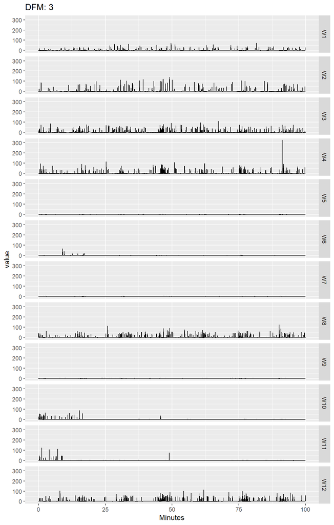

```r
RawDataPlot.DFM(dfm.single,OutputPNGFile = TRUE) # This will save a .png file but will not show one.
BaselinedDataPlot.DFM(dfm.single,range=c(0,100),OutputPNGFile = FALSE) #This will show the plot and not save it to a file.
```

You can overlay the current feeding parameters (*Feeding.Threshold* and *Feeding.Minimum*) on the baselinedata plots as follows (this is currently not available for tasting parameters). Here we present only the first 100 minutes of the experiment by specifying a range parameter.

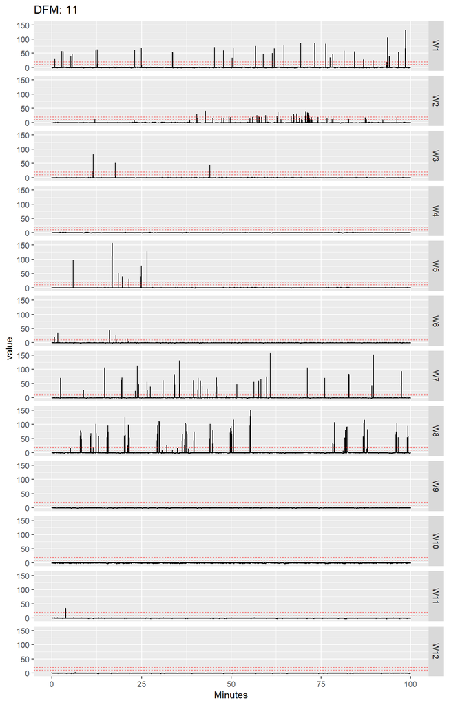

```r
BaselinedDataPlot.DFM(dfm.choice, range=c(0,100), OutputPNGFile = FALSE, IncludeThresholds=TRUE)
```

A simple summary of the licks from one DFM can be obtained with the feeding summary. The format of this object depends on the type of experiment (single-well or choice). This function applies to a single DFM, as noted by the last part of the function name.

```r
# Summarize the first two hours, and don't transform.
summary.onewell<-Feeding.Summary.DFM(dfm.single,range=c(0,120),TransformLicks=FALSE)
summary.choice<-Feeding.Summary.DFM(dfm.choice)
head(summary.onewell)
```

```
##   DFM Chamber Licks Events MeanDuration MedDuration MeanTimeBtw MedTimeBtw
## 1   3       1   545     76     1.518421         1.2    92.85974       81.0
## 2   3       2   795    118     1.384746         1.1    59.50420       41.6
## 3   3       3  1499    175     1.792000         1.6    39.10114       26.2
## 4   3       4  1125    158     1.488608         1.0    44.51698       23.2
## 5   3       5     0      0           NA          NA  9215.20000     9215.2
## 6   3       6    37      3     2.800000         1.6  1885.85000      490.3
##    MeanInt MedianInt MinInt MaxInt StartMin EndMin
## 1 24.68458      22.0      1     72        0    120
## 2 37.17503      32.0      0    140        0    120
## 3 30.16837      27.0     -7    111        0    120
## 4 33.78146      31.0      0    327        0    120
## 5       NA        NA     NA     NA        0    120
## 6 26.07143      21.5      3     65        0    120
```

```r
head(summary.choice)
```

```
##   DFM Chamber         PI    EventPI   LicksA   LicksB EventsA EventsB
## 1  11       1  0.5913978  0.2577320 4.590349 3.267580      61      36
## 2  11       2 -0.4938373 -0.6280702 4.981902 6.529779      53     232
## 3  11       3  0.8095238  0.3548387 3.802214 2.165737      21      10
## 4  11       4 -0.5179487 -0.4877193 4.873262 6.491734      73     212
## 5  11       5  0.9636364  0.8888889 3.833659 1.414214      17       1
## 6  11       6  0.9322034  0.8260870 4.300377 1.861210      21       2
##   MeanDurationA MedDurationA MeanDurationB MedDurationB MeanTimeBtwA
## 1      1.475410          1.2     0.6666667          0.4     345.9548
## 2      2.505660          1.8     1.7000000          1.2     396.4148
## 3      2.066667          2.2     0.4400000          0.4     977.0818
## 4      1.654795          1.2     1.8518868          1.0     289.4378
## 5      2.764706          2.8     0.8000000          0.8    1194.0111
## 6      3.571429          2.6     1.2000000          1.2     975.6455
##   MedTimeBtwA MeanTimeBtwB MedTimeBtwB MeanIntA MedianIntA MinIntA MaxIntA
## 1       167.1    581.49189        53.8 46.27333         37       4     195
## 2       180.6     90.75021         6.8 46.94880         40       0     189
## 3       104.3   1957.70909       177.4 45.18433         39       0     157
## 4       196.7     99.27981         5.6 63.44040         52      -1     276
## 5       234.3  10769.20000     10769.2 42.90638         40       0     130
## 6       264.1   7178.93333      7822.6 41.85333         41       0     129
##   MeanIntB MedianIntB MinIntB MaxIntB StartMin EndMin
## 1 20.98333       21.0      -1      42        0      0
## 2 40.22008       39.0      -1     146        0      0
## 3 22.68182       19.0      11      60        0      0
## 4 45.67091       44.0      -1     170        0      0
## 5 29.25000       28.5      26      34        0      0
## 6 30.25000       24.5      13      82        0      0
```

For single-well experiments, the results are presented as a series of columns in a data frame, the definition of which are as follows:

| Column | Definition |
| --- | --- |
| DFM | The DFM ID number. |
| Chamber | The chamber number (1-12) numbered as in the parameter vector. |
| Licks | The number of feeding licks in the defined range (the entire experiment if not specified). |
| Events | The number of events (groups of contiguous licks) in the defined range. |
| MeanDuration | The mean duration (in seconds) of feeding events. |
| MedDuration | The median duration (in seconds) of feeding events. |
| MeanTimeBtw | The mean time (in seconds) between feeding events. |
| MedTimeBtw | The median time (in seconds) between feeding events. |
| MeanInt | The mean (normalized) signal intensity across all licks. |
| MedianInt | The median (normalized) signal intensity across all licks. |
| MinInt | The minimum signal intensity recorded for any observation considered part of a feeding event. |
| MaxInt | The maximum signal intensity recorded for any observation considered part of a feeding event. |
| StartMin | The start of the range (in minutes) examined (0 = start of experiment). |
| EndMin | The end of the range (in minutes) examined (0 = end of experiment). |

For two-well/choice experiments, the results are presented as a series of columns in a data frame, the definition of which are as follows:

[output not shown]

We have found that the number of licks is not normally distributed and that a transformation to the 0.25 power is appropriate. *Feeding.Summary.DFM()* (and most other functions that output licks) has an option to transform the licks data in this way. Because it is necessary for subsequent statistical analyses (e.g., ANOVA, t-test, etc.), the default behavior is to transform (i.e., *TransformLicks=TRUE* is set in the function definition). Specifying *TransformLicks=FALSE* in the function calls will disable the transformation. As always, details can be obtained from the function body and defintion.

The *Feeding.Summary.DFM()* function summarizes a range of metrics over the entire range specified. If you would like to parse the range into non-overlapping bins and to evaluate the feeding interactions in each bin, there is *BinnedFeeding.Summary.DFM()*, which takes one additional parameter that specifies the size of each bin, in minutes.

```r
# Summarize the first two hours, and don't transform.
binsummary.onewell<-BinnedFeeding.Summary.DFM(dfm.single,binsize.min=10,range=c(0,120),TransformLicks=FALSE)
binsummary.choice<-BinnedFeeding.Summary.DFM(dfm.choice,binsize.min = 30)
head(binsummary.onewell)
```

```
##   Interval Minutes DFM Chamber Licks Events MeanDuration MedDuration
## 1   [0,10]       5   3       1    11      3    0.7333333         0.8
## 2   [0,10]       5   3       2    29      6    1.0000000         0.6
## 3   [0,10]       5   3       3    96     13    1.5692308         1.4
## 4   [0,10]       5   3       4    61     14    0.9000000         0.8
## 5   [0,10]       5   3       5     0      0           NA          NA
## 6   [0,10]       5   3       6    33      2    3.8000000         3.8
##   MeanTimeBtw MedTimeBtw  MeanInt MedianInt MinInt MaxInt StartMin EndMin
## 1   194.10000      162.2 19.36364        18     12     28        0     10
## 2    95.68571       38.0 37.13333        30      6     87        0     10
## 3    53.65714       24.0 27.21569        24      3     85        0     10
## 4    42.08000       27.4 28.33333        23      3     96        0     10
## 5  9215.20000     9215.2       NA        NA     NA     NA        0     10
## 6   337.80000      443.4 26.94737        22      3     65        0     10
```

```r
head(binsummary.choice)
```

```
##   Interval Minutes DFM Chamber         PI    EventPI   LicksA   LicksB EventsA
## 1   [0,30]      15  11       1  1.0000000  1.0000000 2.560750 0.000000       9
## 2   [0,30]      15  11       2  1.0000000  1.0000000 2.114743 0.000000       2
## 3   [0,30]      15  11       3  0.7681159  0.4000000 2.794682 1.681793       7
## 4   [0,30]      15  11       4 -0.5659574 -0.4634146 2.672345 3.683023      11
## 5   [0,30]      15  11       5        NaN        NaN 0.000000 0.000000       0
## 6   [0,30]      15  11       6  1.0000000  1.0000000 1.861210 0.000000       1
##   EventsB MeanDurationA MedDurationA MeanDurationB MedDurationB MeanTimeBtwA
## 1       0     0.9555556          1.0            NA           NA     200.9600
## 2       0     2.0000000          2.0            NA           NA     879.0000
## 3       3     1.8571429          1.8     0.5333333          0.6    1154.2250
## 4      30     0.9818182          0.8     1.3133333          0.6     154.1833
## 5       0            NA           NA            NA           NA   15405.2000
## 6       0     3.2000000          3.2            NA           NA    3912.5000
##   MedTimeBtwA MeanTimeBtwB MedTimeBtwB MeanIntA MedianIntA MinIntA MaxIntA
## 1       114.7   2296.60000      2296.6 36.62791         34      12      68
## 2       688.8   8512.80000      8512.8 31.40000         24      13      82
## 3       156.2   2240.85000       487.8 49.24615         39       1     157
## 4       142.3     56.84516         3.6 38.57407         33       0     114
## 5     15405.2  18772.80000     18772.8       NA         NA      NA      NA
## 6      3912.5   7822.60000      7822.6 20.56250         26       0      35
##   MeanIntB MedianIntB MinIntB MaxIntB StartMin EndMin
## 1       NA         NA      NA      NA        0     30
## 2       NA         NA      NA      NA        0     30
## 3 22.50000       19.5      11      43        0     30
## 4 42.58376       41.0       0     127        0     30
## 5       NA         NA      NA      NA        0     30
## 6       NA         NA      NA      NA        0     30
```

Binned summarys contain the same information and measures as those described above for the general feeding summary functions.

Two simple plotting functions help visualize the data for individual DFMS. The first is *CumulativeLicksPlots.DFM(dfm,SinglePlot=FALSE,TransformLicks=TRUE)*, which presents the accumulation of licks over time. If *SinglePlot=FALSE* (the default behavior), the format of the plot depends on the type of DFM, noting that for choice-chambers, the plot is faceted on WellA and WellB, which are adjusted for PI.Multiplier, and not on the physical location of the wells. However, the color of the lines, which is determined by Well Number and shown in the legend, remains determined by physical location. If *SinglePlot=TRUE* then all lines for both types of DFM represent Well Number and therefore physical location.

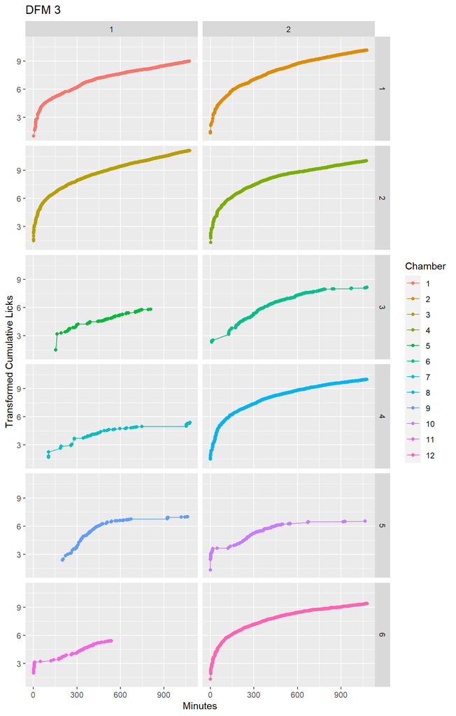

```r
CumulativeLicksPlots.DFM(dfm.single)
```

```
## geom_path: Each group consists of only one observation. Do you need to adjust
## the group aesthetic?
```

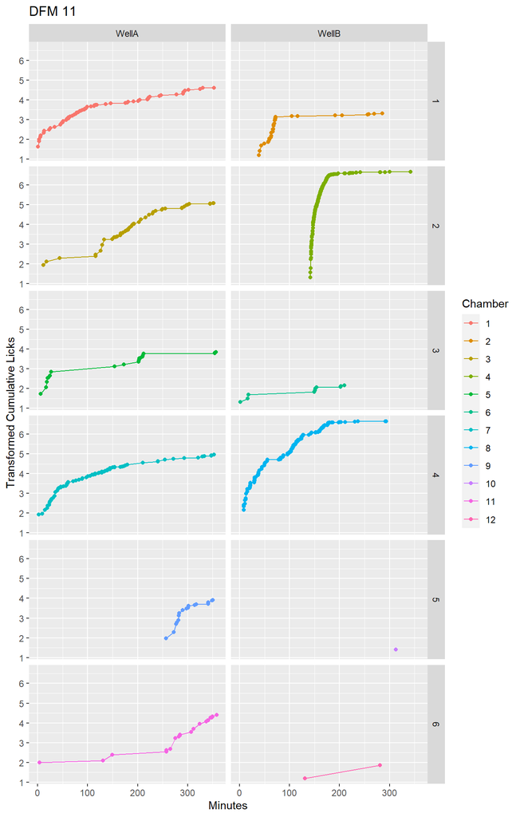

```r
CumulativeLicksPlots.DFM(dfm.choice)
```

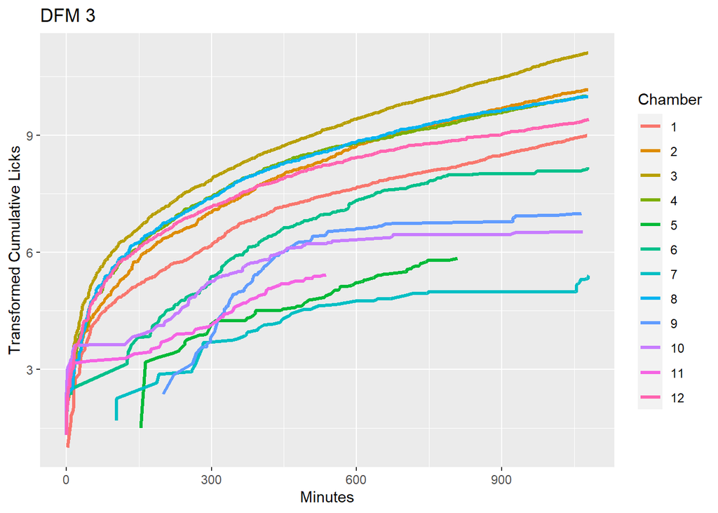

```r
CumulativeLicksPlots.DFM(dfm.single,SinglePlot=TRUE) # If you would rather have them all on one plot
```

A similar function helps visualize binned data from individual DFMs. *BinnedLicksPlot.DFM()* shows a separate line of binned lick data (transformed by default) for each well of single-well chambers or a stacked bar chart showing the WellA or WellB licks (determined by PI.Multiplier) in each of the six chambers.

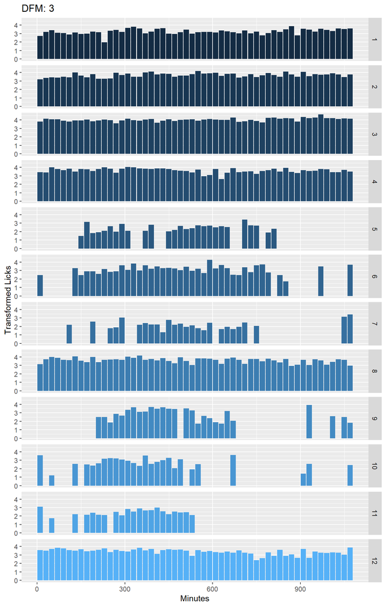

```r
BinnedLicksPlot.DFM(dfm.single,binsize.min=20)
```

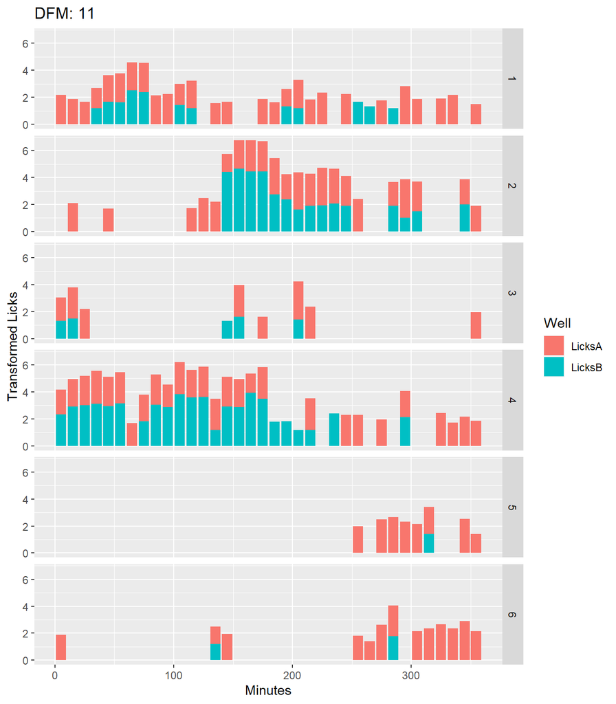

```r
BinnedLicksPlot.DFM(dfm.choice,binsize.min=10)
```

While transforming the licks is best for quantitative analysis, for the purposes of quality checks on the binned data, it is often best to disable this feature.

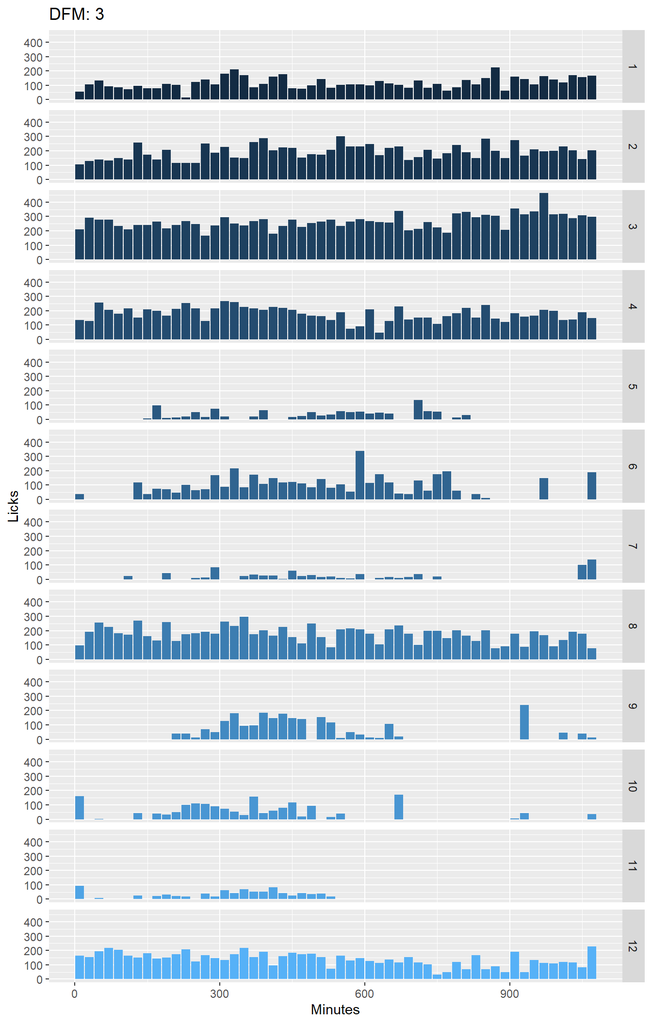

```r
BinnedLicksPlot.DFM(dfm.single,binsize.min=20,TransformLicks=FALSE)
```

## Other General Functions

You can obtain information about feeding intervals and durations for each DFM by

```r
IandD<-GetIntervalData.DFM(dfm.single)
head(IandD)
```

```
##   DFM Chamber Well      Minutes Sample IntervalSec BaselineWindowMin
## 1   3       1    1 3.333333e-05      4       138.6                 3
## 2   3       1    1 2.313417e+00    698       377.2                 3
## 3   3       1    1 8.630000e+00   2590        74.8                 3
## 4   3       1    1 9.890167e+00   2968       185.8                 3
## 5   3       1    1 1.300027e+01   3900        84.2                 3
## 6   3       1    1 1.441677e+01   4323        52.2                 3
##   FeedingThreshold FeedingMinimum TastingLow TastingHigh FeedingMinEvents
## 1               20             10          5          20                1
## 2               20             10          5          20                1
## 3               20             10          5          20                1
## 4               20             10          5          20                1
## 5               20             10          5          20                1
## 6               20             10          5          20                1
##   TastingMinEvents SamplesSec ChamberSize Ch1 Ch2 Ch3 Ch4 Ch5 Ch6 Ch7 Ch8 Ch9
## 1                1          5           1   1   2   3   4   5   6   7   8   9
## 2                1          5           1   1   2   3   4   5   6   7   8   9
## 3                1          5           1   1   2   3   4   5   6   7   8   9
## 4                1          5           1   1   2   3   4   5   6   7   8   9
## 5                1          5           1   1   2   3   4   5   6   7   8   9
## 6                1          5           1   1   2   3   4   5   6   7   8   9
##   Ch10 Ch11 Ch12 Link.Gap PI.Multiplier
## 1   10   11   12        5             0
## 2   10   11   12        5             0
## 3   10   11   12        5             0
## 4   10   11   12        5             0
## 5   10   11   12        5             0
## 6   10   11   12        5             0
```

[output not shown]

You can save the baselined data to a text file for plotting in another program. It will create a .csv file with a reasonable name (e.g., BaselinedData_DFM3.csv for DFM3).

```r
OutputBaselinedData.DFM(DFM11)
OutputBaselinedData.DFM(dfm.choice, range=c(0,100)) # Remember DFM11 and dfm.choice point to the same object.
```

## Function Definition Reference

Listed below are the functions used in this document along with their argument list showing optional parameters and their default values. You should know what each of these functions does and what each argument represents before moving on to the remaining documentation. It is important that these functions, and the larger set of R Code for the FLIC, are not treated as a black box. In our experience the FLIC system provides remarkable insights, but the data sets are large and complex and must be managed carefully to ensure that mistakes are avoided.

```r
ParametersClass.SingleWell()

ParametersClass.TwoWell()

DFMClass(id,parameters,range=c(0,0))

DFMClass.LinkFiles(id,parameters,range=c(0,0))

FindDataBreaks(dfm,multiplier=4,returnvals=TRUE)

ChangeParameterObject(dfm,newP)

FirstSampleData(dfm)

LastSampleData(dfm)

CleanDFM()

Feeding.Summary.DFM(dfm,range=c(0,0),TransformLicks=TRUE)

BinnedFeeding.Summary.DFM(dfm,binsize.min=30,range=c(0,0),TransformLicks=TRUE)

OutputBaselinedData.DFM(dfm, range=c(0,0),filename="Baselined")

GetIntervalData.DFM(dfm,range)

RawDataPlot.DFM(dfm,range=c(0,0),OutputPNGFile=FALSE)

BaselinedDataPlot.DFM(dfm,range=c(0,0),OutputPNGFile=FALSE, IncludeThresholds=FALSE)

BinnedLicksPlot.DFM(dfm,binsize.min=30,range=c(0,0),TransformLicks=TRUE)
```